# Reportes Quarto en R: clase 2

Fecha de publicación

4 de marzo de 2025

En esa clase veremos nuevos elementos para agregar a nuestros reportes, y más maneras de personalizar reportes Quarto.

## Elementos

### Imágenes

Para agregar una imagen en un reporte, se usa un código similar al de los enlaces: `![]()`, poniendo la ruta de la imagen dentro del paréntesis. La ruta de la imágen tiene que ir en relación al documento Quarto.

Por ejemplo, para agregar una imagen que se encuentra en una carpeta `imagenes`:

`![](imagenes/mapache.jpeg)`

### Bloques de código

Si queremos mostrar código dentro de nuestro reporte, pero sin ejecutarlo, o bien, para mostrar código de cualquier otro lenguaje, creamos *bloques* de código usando tildes o comillas invertidas `` ` ``

Para crear un bloque de código, agregamos tres o más comillas invertidas antes y después del código:

````
```
library(dplyr)
iris |>
  filter(Species == "setosa")
```
````

Para que el código aparezca con el formato correcto al lenguaje usado, ponemos el nombre del lenguaje luego de las comillas de apertura del bloque:

Si agregamos la letra `r` a las comillas de apertura:

````
```r
library(dplyr)
iris |>
  filter(Species == "setosa")
```
````

Se produce el siguiente resultado:

```r
library(dplyr)
iris |>
  filter(Species == "setosa")
```

### Enlaces a partes del documento

Podemos crear un enlace dentro de nuestro documento que nos lleve a una posición específica dentro del mismo.

Tenemos que agregar el siguiente código después del título o subtítulo al que queremos apuntar: `{#seccion-importante}`, y luego crear un enlace que apunte al mismo texto del ancla que creamos:

`[Este texto te llevará a otra parte del documento](#seccion-importante)`

Este texto te llevará a otra parte del documento

Esto puede servir para crear índices de manera manual, por ejemplo, para llevar a tus lectores/as a las partes más relevantes de tu reporte, o para referirte a otras secciones de tu reporte y facilitar la navegación para tus usuarios/as.

### Insertar videos

Usando un [shortcode](https://quarto.org/docs/authoring/shortcodes.html), podemos insertar un video de Youtube con facilidad:

```
{{< video https://www.youtube.com/watch?v=093zcHXsKs4 >}}
```

[video not shown]

Si necesitas insertar videos desde otras plataformas, [revisa esta extensión de Quarto](https://github.com/sellorm/quarto-social-embeds), o bien siempre puedes insertar cualquier cosa que desees usando código html directamente en el documento.

### Símbolos

Podemos agregar símbolos a nuestro texto, por ejemplo para agregar a los títulos, en numeraciones, utilizar como un símbolo de información o para destacar algún elemento, [instalando una extensión](https://github.com/quarto-ext/fontawesome) que nos permite poner [símbolos de Font Awesome](https://fontawesome.com/search) en nuestros documentos.

La extensión se llama [`fontawesome`](https://github.com/quarto-ext/fontawesome). Para instalarla, en RStudio, en la pestaña de *Terminal* (al lado de la pestaña de Consola), ejecuta el siguiente código:

```bash
quarto add quarto-ext/fontawesome
```

Una vez instalada, puedes agregar símbolos con el shortcode `fa` seguido del nombre del ícono (que encuentras en el sitio web de [Font Awesome](https://fontawesome.com/search)):

```
Casas {{< fa house >}}
```

Puedes encontrar [más extensiones de Quarto en este enlace](https://quarto.org/docs/extensions/)

### Avisos

Crea fácilmente recuadros que destaquen alguna alerta, información o consejo en tu documento, [creando un bloque de avisos (*callouts*)](https://quarto.org/docs/authoring/callouts.html):

```markdown
:::{.callout-warning title="Aviso" appearance="simple"}
Este es un aviso muy importante!
:::
```

**Aviso**

Este es un aviso muy importante!

## Personalización

### Cambiar colores del documento

Desde el encabezado de un documento cuarto podemos agregar etiquetas que nos permiten cambiar fácilmente los colores de un documento. Los códigos necesarios para cambiar los tres colores más comunes de un documento (fondo, texto y enlaces) son los siguientes:

```yaml
# colores del texto
backgroundcolor: "#F0EDCC"
fontcolor: "#02343F"
linkcolor: "#02343F"
```

### Modificar estilos CSS

Poema especificar el estilo de cualquier palabra, oración o elemento de nuestro documento si es que está entre corchetes y agregamos llaves después del corchete de cierre con un estilo CSS personalizado.

Por ejemplo, si queremos hacer que una imagen no sea tan ancha, agregamos el estilo `width:40%;`:

`![](imagenes/mapache.jpeg){style="width:40%;"}`

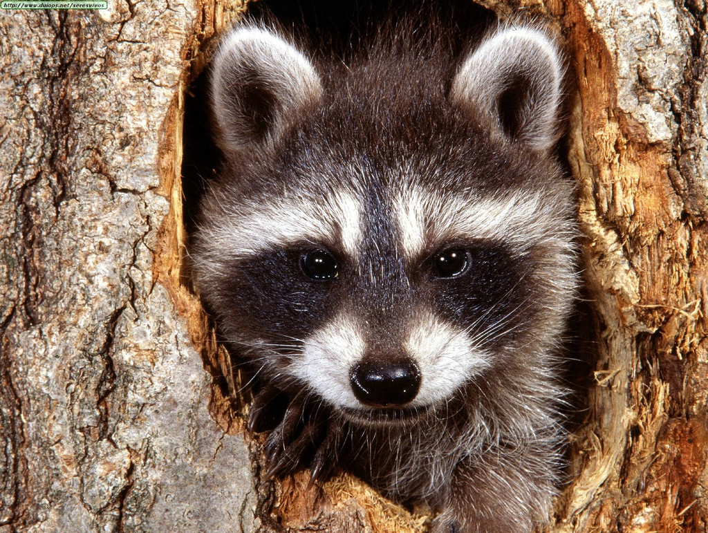

También podemos cambiar el estilo específico de una palabra.

`Estilo de [una palabra.]{style="color: pink;"}`

O cambiar el tamaño de un texto.

`[tamaño]{style="font-size:200%;"} de un texto.`

### Modificar hoja de estilos CSS

Si la personalización que queremos realizar es más general a través de nuestros documentos, podemos modificar la hoja de estilos CSS del documento completo, para definir estilos para elementos determinados, tales como títulos, subtítulos, párrafos, enlaces y más.

Para esto, primero tenemos que crear la hoja de estilos. Crea un archivo vacío desde RStudio que tenga la extensión `.css`, por ejemplo `estilos.css`. Dentro de este documento puedes utilizar el código CSS para cambiar el estilo de cualquier elemento, o de cualquier clase usada en el documento.

Luego, tienes que especificar que tu documento Quarto utilice la hoja de estilo que creaste. Agrega al siguiente código en el encabezado:

```yaml
css: estilos.css
```

Dentro de la hoja de estilos, puedes cambiar la apariencia de los títulos principales (`h1`), títulos secundarios (`h2`, `h3`, `h4`, etc.), enlaces (`a`), párrafos (`p`), y más.

Por ejemplo, para cambiar los colores de los títulos de nivel dos, agregamos al siguiente código a la hoja de estilos `estilos.css`:

```css
h2 {
  color: #d3687f;
  margin-top: 64px;
}
```

Si queremos agrandar o achicar el texto de un título en específico, agregamos el siguiente código a la hoja de estilos:

```css
h3 {
  font-size: 110%;
}
```

### Crear clases CSS

Dentro de la hoja de estilos CSS puedes crear tus propias *clases*. Las clases son estilos personalizados que puedes aplicar fácilmente a cualquier otro elemento de tu documento si es que defines que el elemento es de la clase específica.

Ejemplo, en la hoja de estilos CSS `estilos.css` creamos una nueva clase llamada `.detalle` (los estilos nuevos tienen que empezar con un punto), y luego podemos aplicar este estilo a un párrafo, por ejemplo, si encerramos el párrafo en corchetes y agregamos al final dentro de una llave el nombre de la clase que creamos:

```css
.detalle {
  color: #f9f9f9;
  background-color: grey;
  padding: 3px;
  border-radius: 5px;
}
```

`[Usar una clase definida en al hoja de estilos]{.detalle}`

Usar una clase definida en al hoja de estilos

### Usar tipografías web

Podemos cambiar la tipografía de nuestro documento por cualquier tipografía web, por ejemplo las de [Google Fonts](https://fonts.google.com), si seguimos las instrucciones de Google Fonts para cargar la tipografía desde la hoja de estilos.

Por ejemplo, si encontramos la tipografía Montserrat y queremos usarla en nuestro documento, vemos que el código de inserción CSS es el siguiente:

```css
@import url('https://fonts.googleapis.com/css2?family=Montserrat:ital,wght@0,100..900;1,100..900&display=swap');
$font-family-sans-serif: "Montserrat", sans-serif;
```

Entonces agregamos este código a nuestra hoja de estilos CSS, y además especificamos en el encabezado de nuestro documento que queremos usar esta tipografía como el texto principal del documento:

```yaml
mainfont: Montserrat
```

### Bloques HTML

Podemos cambiar o especificar el estilo de cualquier contenido de nuestros documentos cuarto si creamos un bloque al cual le especificamos un estilo en específico. Para crear un bloque, encierra el texto o código entre tres símbolos de dos puntos consecutivos, y especifica en el inicio del bloque los estilos CSS que deseas para el contenido.

Por ejemplo, este es un bloque al cual definimos un estilo para que el texto sea más pequeño y aparezca en metálicas y en gris. Todo lo que pongamos dentro de este texto y dentro del bloque aparecerá con ese estilo, y al cerrar el bloque se vuelve a usar el estilo normal del reporte.

El bloque anterior fue definido con el siguiente código:

```markdown
::: {style="font-size: 80%; line-height: 1.2; color: #B5B5B5; font-style: italic;"}

(contenido)

:::
```

También puede resultar útil crear bloques que hagan que sus contenidos se encuentren dentro de un cuadro de un largo específico, de manera que el contenido dentro del cuadro puede ser más largo y el usuario o usuario pueda desplazarse por el contenido haciendo scrolling:

```
    Sepal.Length Sepal.Width Petal.Length Petal.Width    Species
1            5.1         3.5          1.4         0.2     setosa
2            4.9         3.0          1.4         0.2     setosa
3            4.7         3.2          1.3         0.2     setosa
4            4.6         3.1          1.5         0.2     setosa
5            5.0         3.6          1.4         0.2     setosa
6            5.4         3.9          1.7         0.4     setosa
7            4.6         3.4          1.4         0.3     setosa
8            5.0         3.4          1.5         0.2     setosa
9            4.4         2.9          1.4         0.2     setosa
10           4.9         3.1          1.5         0.1     setosa
11           5.4         3.7          1.5         0.2     setosa
12           4.8         3.4          1.6         0.2     setosa
13           4.8         3.0          1.4         0.1     setosa
14           4.3         3.0          1.1         0.1     setosa
```

[output cut: 136 more lines]

El bloque anterior contiene una gran cantidad de datos, pero estos datos no llenan la hoja porque están dentro de un bloque con un largo definido. El código usado fue el siguiente:

````markdown
::: {style="max-height: 200px; overflow-y: scroll;"}
```{r}
#| echo: false
iris
```
:::
````

## Inclusiones

Si generamos contenido en otros documentos Quarto, podemos *incluir* este contenido en el documento mediante el *shortcode* de inclusión (*include*):

```
{{< include quarto_reportes/iris_normal.qmd >}}
```

Dentro del *shortcode* va el nombre del documento Quarto. El contenido de este documento aparecerá dentro del documento donde lo insertes como si fuera parte del mismo, incluso apareciendo en la tabla de contenido.

## Generar contenido del reporte desde loops

Dentro de un *chunk* de código, podemos usar funciones que entreguen como output código markdown. Esto nos servirá para construir un documento a partir de un loop o iteración. De este modo, podemos usar nuestros datos para generar una cantidad indeterminada de títulos, subtítulos, párrafos de textos, gráficos o más, que se generarán automáticamente.

Usaremos el paquete `{pander}` para que el chunk de R retorne contenido en Markdown que Quarto interpretará como parte del documento gracias a la opción `results: asis` definida al principio del chunk:

```r
library(pander)
library(dplyr)

largo_petalo <- iris |>
  slice_max(Petal.Length) |>
  pull(Petal.Length) |>
  unique()

pandoc.p(paste("La observación más alta en largo de pétalos es:", largo_petalo))
```

La observación más alta en largo de pétalos es: 6.9

Las funciones `pandoc.header()` y `pandoc.p()` sumadas a la opción `results: asis` nos ayudan a que el chunk retorne texto en markdown. Usando los mismos principios, podemos programar un loop que vaya retornando títulos, textos, y más, para que el contenido del documento se vaya escribiendo solo. Si queremos incluir gráficos, tenemos que imprimirlos explícitamente con `plot()`.

Luego del código veremos el contenido resultante, generado de forma automática:

```r
library(ggplot2)
library(pander)
library(dplyr)

# iteración por cada valor de la columna `Species`
for (especie in unique(iris$Species)) {
  # especie = "setosa"

  # título con el nombre de la especie
  pandoc.header(especie, level = 3)

  # gráfico de dispersión destacando la especie
  grafico <- iris |>
    ggplot() +
    aes(x = Sepal.Length, y = Sepal.Width, color = Species) +
    geom_point() +
    theme_void() +
    # destacar la especie
    gghighlight::gghighlight(Species == "setosa")

  # imprimir gráfico
  plot(grafico)

  # obtener una cifra
  largo_petalo <- iris |>
    filter(Species == especie) |>
    slice_max(Petal.Length) |>
    pull(Petal.Length) |>
    unique()

  # incluir cifra como texto redactado
  pandoc.p(paste("La observación más alta en largo de pétalos es:", largo_petalo))

  # barra horizontal
  pandoc.horizontal.rule()
}
```

[output not shown]

### setosa

La observación más alta en largo de pétalos es: 1.9

### versicolor

La observación más alta en largo de pétalos es: 5.1

### virginica

La observación más alta en largo de pétalos es: 6.9

Usando esta técnica podemos producir documentos muy extensos con poco código, lo que nos vuelve más eficientes y también nos ayuda para actualizar y retocar los reportes, dado que un cambio hecho una sola vez se replica en todos los elementos generados por el loop.